# Workshop: Crítica e Imputação de Dados no R: Validate

Vitor Marinho

2023-09-19

## Escrevendo e aplicando regras de críticas usando `validate`

O pacote validate do R é uma ferramenta poderosa que pode ser usada para validar dados e garantir a qualidade dos resultados de um projeto. Ele oferece uma variedade de funções que podem ser usadas para verificar a validade de dados, incluindo:

- **Validação de tipos de dados:** O pacote validate pode ser usado para verificar se os dados estão no formato correto. Por exemplo, você pode usar a função `is.numeric()` para verificar se uma variável é um número.
- **Validação de valores:** O pacote validate pode ser usado para verificar se os valores estão dentro de um intervalo aceitável. Por exemplo, você pode usar a função `between()` para verificar se um valor está entre dois valores especificados.
- **Validação de regras:** O pacote validate pode ser usado para verificar se os dados atendem a regras específicas. Por exemplo, você pode usar a função `validate()` para verificar se um valor é maior que outro valor.

Confrontar os dados com as regras e armazenar os resultados

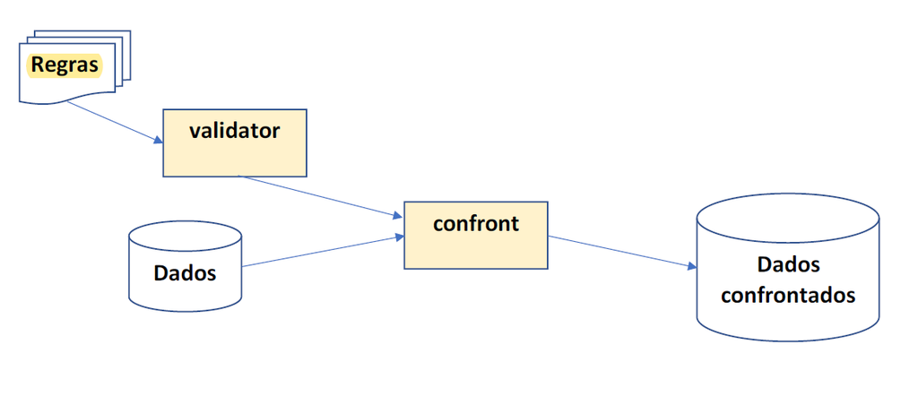

Regras de crítica são expressões que são avaliadas ao ser confrontadas com dados, e resultam em um objeto do tipo ‘logical’ (TRUE ou FALSE)

Verificações de tipo da variável: is.numeric, is.character,. . .

Comparações: <, <=, ==, identical, !=, %in%, >=, >

Operadores lógicos: |, &, if, !, all, any

# Padronização nas regras de crítica

A padronização dos nomes permite que seja possível a identificação da classificação da regra e a presenção do atributo de flexilidade. Define-se a seguinte proposta de nomemclatura para as regras de crítica, conforme Silva (2020):

*1 carácter indicando finalidade + 1 carácter indicando flexibilidade + Sequência numérica*

**Classificação por finalidade**

- Tipo (T)
- Validade ou Intervalo (V)
- Fluxo (F)
- Consistência (C)
- Distribuição (D)

**Classificação por flexibilidade**

- Flexível (F)
- Inflexível (I)

**Exemplos**

TI01: regra de tipo e inflexível

VI08: regra de validade e inflexível

CF02: regra de consistência e flexível

Por definição, regras da classe tipo, validade e fluxo são inflexíveis. As regras da classe consistência podem ser flexíveis e inflexíveis e, por fim, a regra do tipo distribuição é sempre flexível.

# Leitura dos dados

```r
# Instale o pacote validate
# install.packages("validate")

# Importe o pacote validate
library(validate)

# Carregando dados
library(readxl)
dados <- read_excel("dados_simulados.xlsx")

head(dados)
```

```
## # A tibble: 6 × 24
##     IBGE7 S_TXBRUTAMORT S_TXBRUTAMORT_t_1 S_TXBRUTAMORTPAD S_TXMOISQCOR45A59
##     <dbl>         <dbl>             <dbl>            <dbl>             <dbl>
## 1 3100104          6.63              7.49             5.27              68.0
## 2 3100203          6.90              6.69             5.55              41.1
## 3 3100302          6.97              6.55             5.41              56.2
## 4 3100401          7.22              7.36             5.46              40.0
## 5 3100500          6.13              5.83             4.72              59.4
## 6 3100609          4.98              5.43             4.33              34.6
## # ℹ 19 more variables: S_TXMOAVC45A59 <dbl>, S_TXMOATRA15A29 <dbl>,
## #   S_TXMOHOMI <dbl>, S_TXMOHOMI15A29 <dbl>, S_TXMOCANCOLUT <dbl>,
## #   S_TXMOCANMA <dbl>, S_TXMOCANPUL <dbl>, S_OBITO60 <dbl>,
## #   S_NASCBAIXOPESO <dbl>, S_OBINFSIFILS <dbl>, S_OBTETANONEO <dbl>,
## #   S_OBRAIVA <dbl>, S_INTERDVHID <dbl>, S_INTERDRSAI <dbl>, S_COBPSF <dbl>,
## #   S_NASC7CONSUL <dbl>, D_POPP0 <dbl>, D_POPT <dbl>, U_CONSSAU <chr>
```

A função `validator` serve para definir um conjunto de regras de críticas que podem ser aplicadas a diferentes tipos de conjuntos de dados.

**Verificar valores nulos:**

- Verifique se não há valores nulos em colunas críticas, como “IBGE7,” e outras colunas-chave.

**Validar faixas de valores:**

- Verifique se os valores em colunas numéricas estão dentro de faixas aceitáveis, por exemplo, garantir que as taxas estejam entre 0 e 100.

**Verificar valores ausentes em grupos de colunas relacionadas:**

- Verifique se as colunas relacionadas, como as taxas de mortalidade, têm valores ausentes em conjunto.

**Verificar valores booleanos:**

- Verifique se as colunas com valores lógicos (TRUE/FALSE) estão preenchidas corretamente.

**Validar que certas colunas não possuem valores nulos e são numéricas:**

- Certifique-se de que determinadas colunas têm valores numéricos válidos e não nulos.

A função `confront` serve para aplicar o conjunto de regras de crítica a uma base de dados específica.

# Regras de tipo (T)

```r
# Crie um conjunto de regras de validade
regras_tipo <- validator(
  #Taxa bruta de mortalidade
  TI01 = is.numeric(S_TXBRUTAMORT),
  #Taxa de mortalidade por homicídio da população total
  TI02 = is.numeric(S_TXMOHOMI),
  #Taxa de mortalidade por homicídio da população de 15 a 29 anos
  TI03 = is.numeric(S_TXMOHOMI15A29),
  #Mortalidade proporcional da população idosa
  TI04 = is.numeric(S_OBITO60),
  #Proporção de nascidos vivos com baixo peso
  TI05 = is.numeric(S_NASCBAIXOPESO),
  #Casos confirmados notificados de sífilis congênita em menores de 1 ano
  TI06 = is.numeric(S_OBINFSIFILS),
  #Casos confirmados notificados de raiva humana
  TI07 = is.numeric(S_OBRAIVA),
  #Proporção de internações por doenças de veiculação hídrica
  TI08 = is.numeric(S_INTERDVHID),
  #Proporção de internações por doenças relacionadas ao saneamento ambiental inadequado
  TI09 = is.numeric(S_INTERDRSAI),
  #Existência de Conselho Municipal de Saúde
  TI10 = is.character(U_CONSSAU)
)

# Aplica regras de crítica aos dados
base_conf_tipo <- confront(dados, regras_tipo)

# Obtém resumo da aplicação das regras aos dados
summary(base_conf_tipo)
```

```
##    name items passes fails nNA error warning                  expression
## 1  TI01     1      1     0   0 FALSE   FALSE   is.numeric(S_TXBRUTAMORT)
## 2  TI02     1      1     0   0 FALSE   FALSE      is.numeric(S_TXMOHOMI)
## 3  TI03     1      1     0   0 FALSE   FALSE is.numeric(S_TXMOHOMI15A29)
## 4  TI04     1      1     0   0 FALSE   FALSE       is.numeric(S_OBITO60)
## 5  TI05     1      1     0   0 FALSE   FALSE is.numeric(S_NASCBAIXOPESO)
## 6  TI06     1      1     0   0 FALSE   FALSE   is.numeric(S_OBINFSIFILS)
## 7  TI07     1      1     0   0 FALSE   FALSE       is.numeric(S_OBRAIVA)
## 8  TI08     1      1     0   0 FALSE   FALSE    is.numeric(S_INTERDVHID)
## 9  TI09     1      1     0   0 FALSE   FALSE    is.numeric(S_INTERDRSAI)
## 10 TI10     1      1     0   0 FALSE   FALSE     is.character(U_CONSSAU)
```

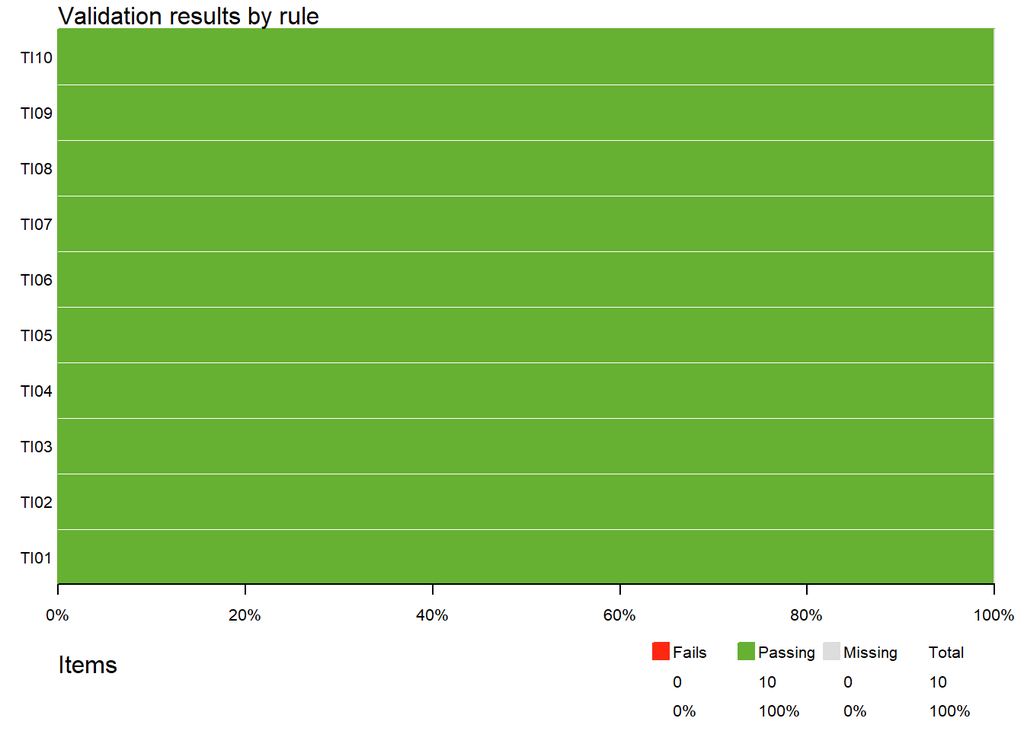

```r
# gráfico
plot(base_conf_tipo)
```

# Regras de validade (V)

```r
regras_validade <- validator(
  #Taxa bruta de mortalidade
  VI01 = (S_TXBRUTAMORT>= 0),
  #Taxa de mortalidade por homicídio da população total
  VI02 = (S_TXMOHOMI >= 0),
  #Taxa de mortalidade por homicídio da população de 15 a 29 anos
  VI03 = (S_TXMOHOMI15A29 >= 0),
  #Mortalidade proporcional da população idosa
  VI04 = (S_OBITO60 >= 0),
  #Proporção de nascidos vivos com baixo peso
  VI05 = (S_NASCBAIXOPESO >= 0 & S_NASCBAIXOPESO <= 100),
  #Casos confirmados notificados de sífilis congênita em menores de 1 ano
  VI06 = (S_OBINFSIFILS >= 0),
  #Casos confirmados notificados de raiva humana
  VI07 = (S_OBRAIVA >= 0),
  #Proporção de internações por doenças de veiculação hídrica
  VI08 = (S_INTERDVHID >= 0 & S_INTERDVHID <= 100),
  #Proporção de internações por doenças relacionadas ao saneamento ambiental inadequado
  VI09 = (S_INTERDRSAI >= 0 & S_INTERDRSAI <= 100),
  #Existência de Conselho Municipal de Saúde
  VI10 = (U_CONSSAU %in% c("Sim","Não"))
)

# Aplica regras de crítica aos dados
base_conf_validade <- confront(dados, regras_validade)

# Obtém resumo da aplicação das regras aos dados
summary(base_conf_validade)
```

```
##    name items passes fails nNA error warning
## 1  VI01   853    853     0   0 FALSE   FALSE
## 2  VI02   853    819     0  34 FALSE   FALSE
## 3  VI03   853    853     0   0 FALSE   FALSE
## 4  VI04   853    853     0   0 FALSE   FALSE
## 5  VI05   853    853     0   0 FALSE   FALSE
## 6  VI06   853    853     0   0 FALSE   FALSE
## 7  VI07   853    853     0   0 FALSE   FALSE
## 8  VI08   853    853     0   0 FALSE   FALSE
## 9  VI09   853    853     0   0 FALSE   FALSE
## 10 VI10   853    835    18   0 FALSE   FALSE
##                                                          expression
## 1                                     (S_TXBRUTAMORT - 0 >= -1e-08)
## 2                                        (S_TXMOHOMI - 0 >= -1e-08)
## 3                                   (S_TXMOHOMI15A29 - 0 >= -1e-08)
## 4                                         (S_OBITO60 - 0 >= -1e-08)
## 5  (S_NASCBAIXOPESO - 0 >= -1e-08 & S_NASCBAIXOPESO - 100 <= 1e-08)
## 6                                     (S_OBINFSIFILS - 0 >= -1e-08)
## 7                                         (S_OBRAIVA - 0 >= -1e-08)
## 8        (S_INTERDVHID - 0 >= -1e-08 & S_INTERDVHID - 100 <= 1e-08)
## 9        (S_INTERDRSAI - 0 >= -1e-08 & S_INTERDRSAI - 100 <= 1e-08)
## 10                                (U_CONSSAU %vin% c("Sim", "Não"))
```

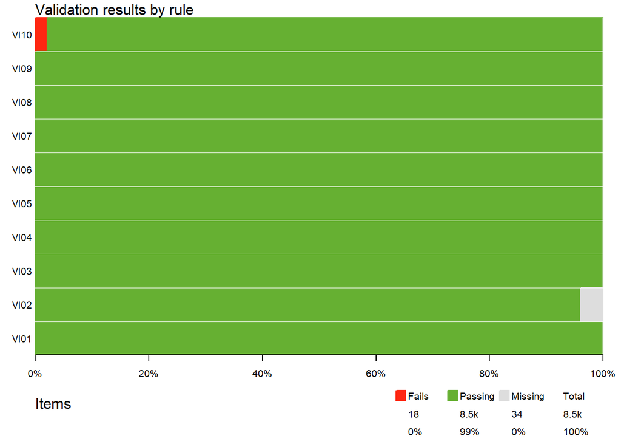

```r
# gráfico
plot(base_conf_validade)
```

# Regras de consistência (C)

```r
regras_consistencia <- validator(
  #Taxa bruta de mortalidade
  CF01 = (S_TXBRUTAMORT/S_TXBRUTAMORT_t_1) <= 1.10,
  #Casos confirmados notificados de sífilis congênita em menores de 1 ano
  CI06 = (S_OBINFSIFILS <= D_POPP0),
  #Casos confirmados notificados de raiva humana
  CI07 = (S_OBRAIVA <= D_POPT)
)

# Aplica regras de crítica aos dados
base_conf_consistencia <- confront(dados, regras_consistencia)

# Obtém resumo da aplicação das regras aos dados
summary(base_conf_consistencia)
```

```
##   name items passes fails nNA error warning
## 1 CF01   853    805    48   0 FALSE   FALSE
## 2 CI06   853    853     0   0 FALSE   FALSE
## 3 CI07   853    853     0   0 FALSE   FALSE
##                                 expression
## 1 (S_TXBRUTAMORT/S_TXBRUTAMORT_t_1) <= 1.1
## 2       (S_OBINFSIFILS - D_POPP0 <= 1e-08)
## 3            (S_OBRAIVA - D_POPT <= 1e-08)
```

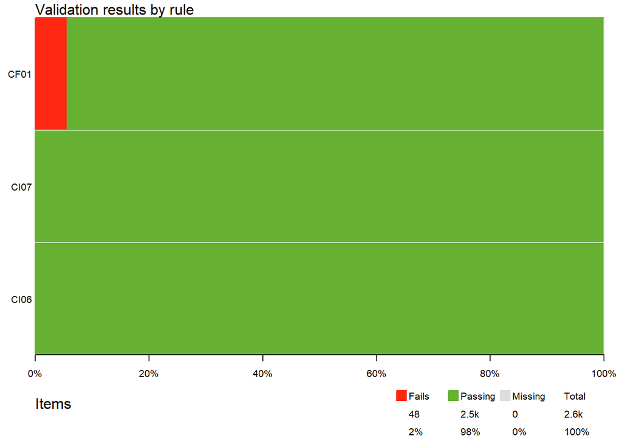

```r
# gráfico
plot(base_conf_consistencia)
```

# Regras de distribuição (D)

```r
regras_distribuicao <- validator(
    #Casos confirmados notificados de sífilis congênita em menores de 1 ano
  DF01 = (S_OBINFSIFILS  < 5),
  #Casos confirmados notificados de raiva humana
  DF02 = (S_OBRAIVA < 5),
  #Proporção de internações por doenças de veiculação hídrica
  DF03 = (mean(S_INTERDVHID) <= 4),
  #Proporção de internações por doenças relacionadas ao saneamento ambiental inadequado
  DF04 = (mean(S_INTERDRSAI) <= 4),
  #Existência de Conselho Municipal de Saúde
  DF05 = (mean(U_CONSSAU=="Sim") >= 0.95)
)
# Aplica regras de crítica aos dados
base_conf_distribuicao <- confront(dados, regras_distribuicao)

# Obtém resumo da aplicação das regras aos dados
summary(base_conf_distribuicao)
```

```
##   name items passes fails nNA error warning                         expression
## 1 DF01   853    825    28   0 FALSE   FALSE                (S_OBINFSIFILS < 5)
## 2 DF02   853    852     1   0 FALSE   FALSE                    (S_OBRAIVA < 5)
## 3 DF03     1      1     0   0 FALSE   FALSE          (mean(S_INTERDVHID) <= 4)
## 4 DF04     1      1     0   0 FALSE   FALSE          (mean(S_INTERDRSAI) <= 4)
## 5 DF05     1      1     0   0 FALSE   FALSE (mean(U_CONSSAU == "Sim") >= 0.95)
```

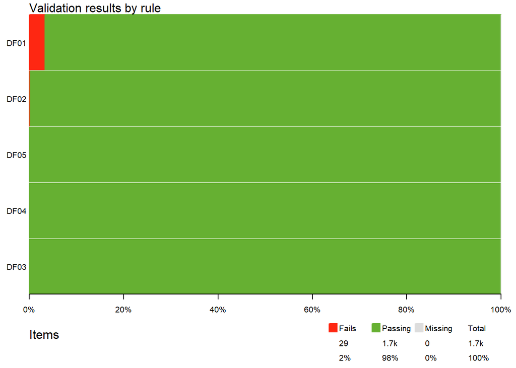

```r
# gráfico
plot(base_conf_distribuicao)
```

# Referências

Silva, P.L.d.N. (2020). Crítica e Imputação de Dados. Notas de aula - Escola Nacional de Ciências Estatísticas.

van der Loo, M. P. J., & de Jonge, E. (2021). Data Validation Infrastructure for R. Journal of Statistical Software, 97(10), 1–31. https://doi.org/10.18637/jss.v097.i10